# Poudre River Discharge Data

13 July, 2026

# 1 Cache la Poudre River

The Cache la Poudre River is located east of the Continental Divide, in the northern Front Range of Colorado. It is affectionately known as the “Poudre” by local residents and long-time visitors to the area. The main and south forks of the Poudre originate in Rocky Mountain National Park, then flows north and east through the Roosevelt National Forest. The river eventually passes through the City of Fort Collins, then joins the south Platte River east of Greeley.

[Source](https://www.rivers.gov/rivers/cache-la-poudre.php)

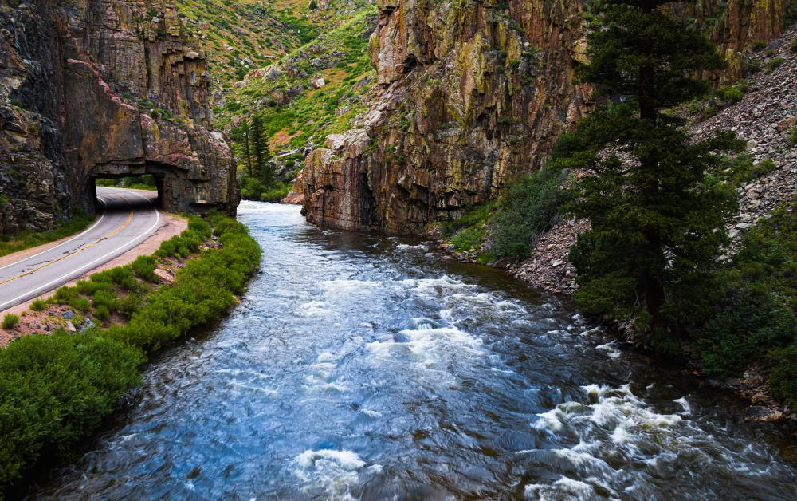

# 2 Methods

The Poudre River at Lincoln Bridge is:

- Downstream of a bit of urban storm water
- Near Odell Brewing Co.
- Near an open area, and the Poudre River Trail
- Downstream of many agricultural diversions

## 2.1 Site Description

[figure not shown]

Station operated by the U.S. Geological Survey in cooperation with [City of Fort Collins.](https://www.fcgov.com/) This station is managed by the Lakewood Field Office.

## 2.2 Data Collection and Plots

Data from [USGS 06752260 CACHE LA POUDRE RIVER AT FORT COLLINS, CO](https://waterdata.usgs.gov/usa/nwis/uv?06752260)

### 2.2.1 Download Data

```r
q <- readNWISdv(siteNumbers = "06752260",
                parameterCd = "00060",
                startDate = "1990-01-01",
                endDate = "2026-06-30") %>%

rename(q = "X_00060_00003")
```

```
## GET: https://waterservices.usgs.gov/nwis/dv/?site=06752260&format=waterml%2C1.1&ParameterCd=00060&StatCd=00003&startDT=1990-01-01&endDT=2026-06-30
```

### 2.2.2 Data Plot

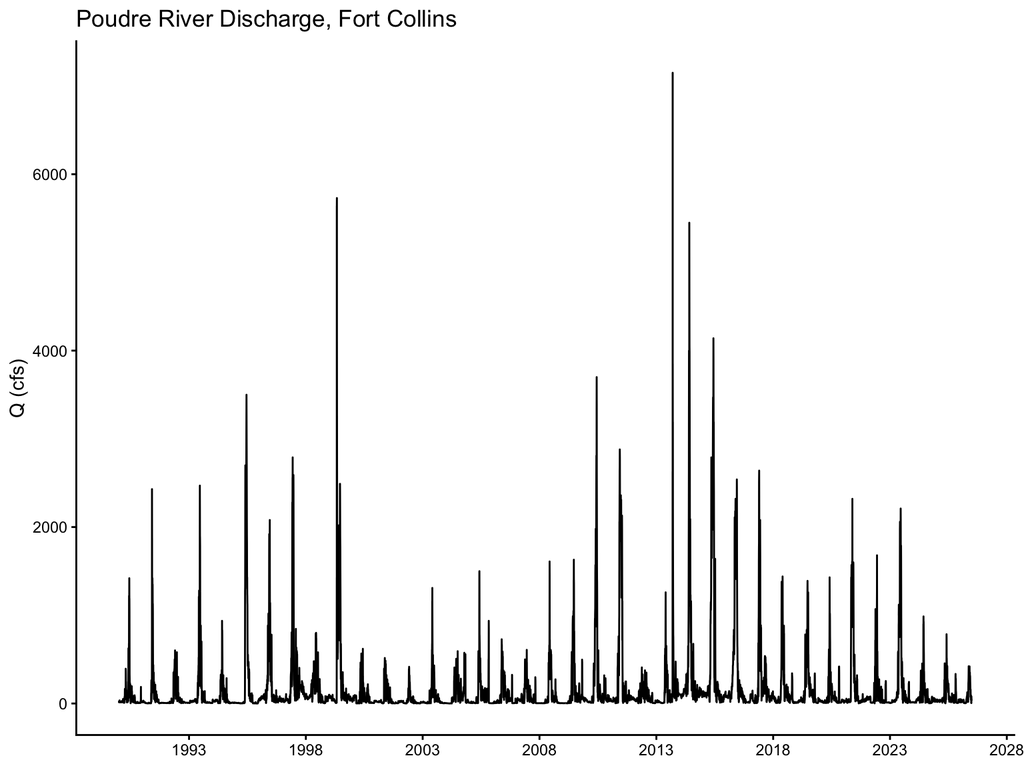

```r
ggplot(q, aes(x = Date, y = q)) +
  geom_line() +
  scale_x_date(date_breaks = "5 years",
               date_labels = "%Y") +
  labs(title = "Poudre River Discharge, Fort Collins",
       x = NULL,
       y = "Q (cfs)") +
  theme_classic()
```

### 2.2.3 Interactive Data Plot

```r
#indicate time-series data
q_xts <- xts(q$q, order.by = q$Date)

dygraph(q_xts) %>%
  dyAxis("y", label = "Discharge (cfs)")
```

[interactive chart not shown]

# 3 Results

- The river has detailed discharge records going back to 1884 (Colorado Department of Natural Resources).
- There are 3 main sources
  - Native River Water
  - C-BT System Water
  - Other Trans-basin Supplies
- Approximately 65% is from snow melt
- Source of the river is from Poudre Lake
- Peak discharge is in the summer; winter flows are very low

## 3.1 Discussion

- How does the source of the Poudre River affect discharge?
- What are the causes of the seasonal variations?
- What are the differences between a wet year, dry year, and average year?
- Can we overlay Sun intensity data over the river discharge data?
- Why was the discharge volume so low in the 2000s?
- Who has what rights to use the water?